[figure not shown]

# Finding groups: k-means and DBSCAN

MY202 · Lab 8

Jonas Weinert

Department of Methodology | London School of Economics and Political Science

19 November 2026

## Lab overview

| Part | Topic | Notebook | Mode | Time |
| --- | --- | --- | --- | --- |
|  | Setup, and what clustering is | lines 9–45 | together | 6 min |
| I | **k-means**: ice-cream carts in a park, then last week’s map | lines 47–130 | concept → code together → your turn | 43 min |
| II | **DBSCAN**: a queue and a picnic, then the same map | lines 132–232 | concept → run together → your turn | 34 min |
|  | Wrap-up: k-means or DBSCAN? |  |  | 6 min |

Last week we squeezed many **columns** into two. Today we sort the **rows** into groups. Still unsupervised: there is no right answer to score against, so every result has to be **read and judged**.

## What is clustering?

WhatI · k-meansII · DBSCANWrap-up

**Notebook** lines 9–34 the overview and the table of methods*concept*

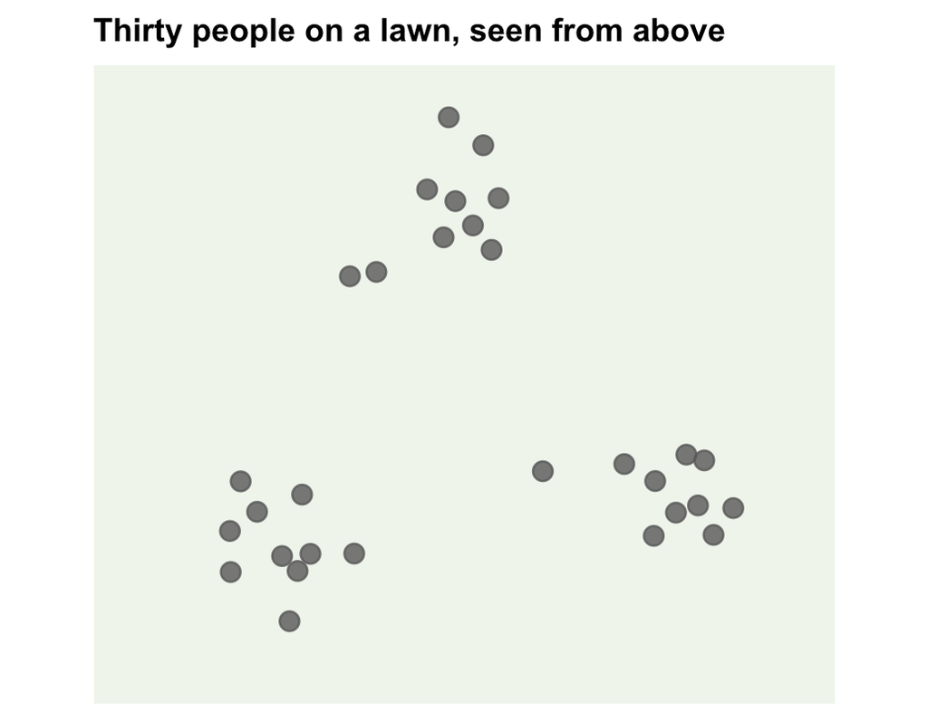

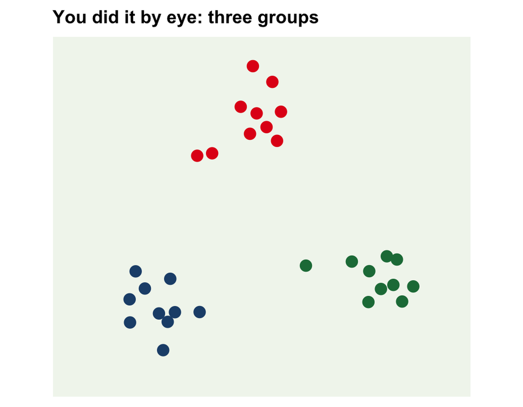

How many groups of friends are on this lawn? How did you decide?

Close together = a group Nobody told you who belongs with whom. You used one thing only: **distance**.

Clustering does this for a table Rows are the dots, columns are the directions. It adds one new column: a **group number** per row.

No outcome, so no accuracy The groups are a **suggestion**. You judge whether they mean anything.

# k-means

Part I

You choose the number of groups, *k* · the algorithm finds them

## k-means: three carts in a park

WhatI · k-meansII · DBSCANWrap-up

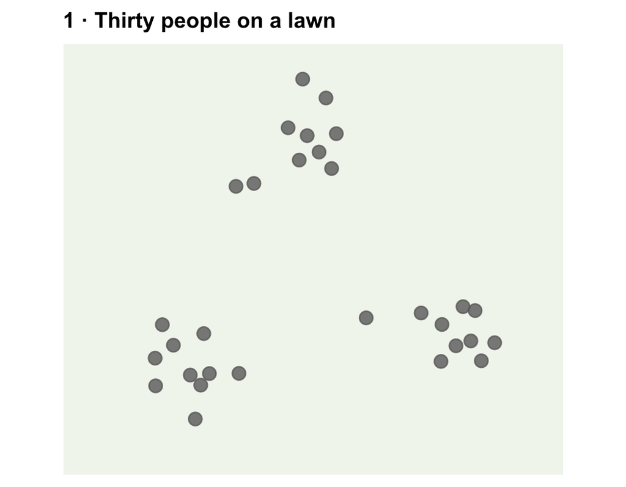

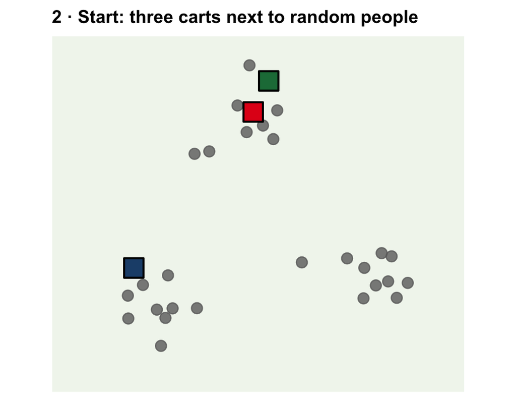

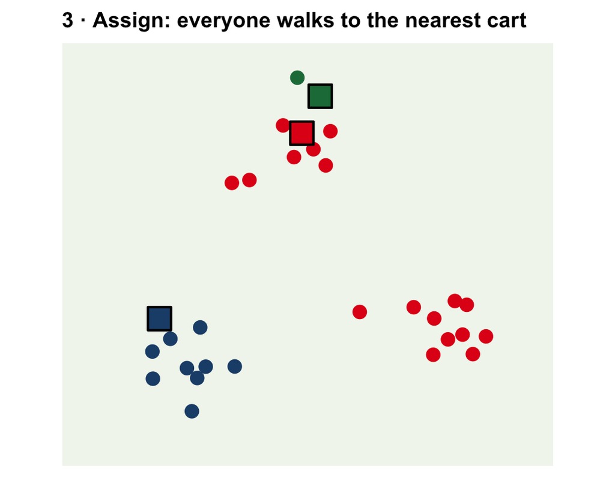

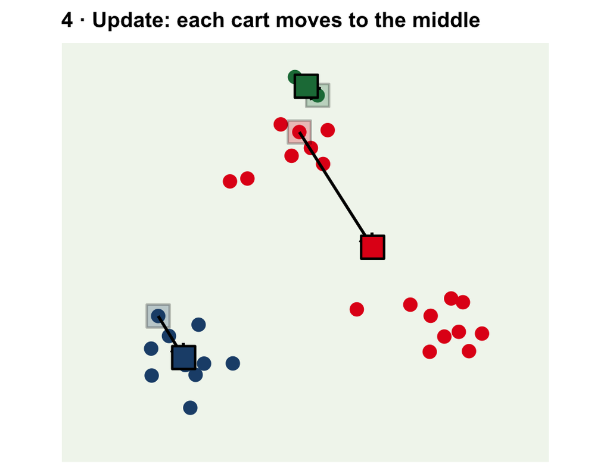

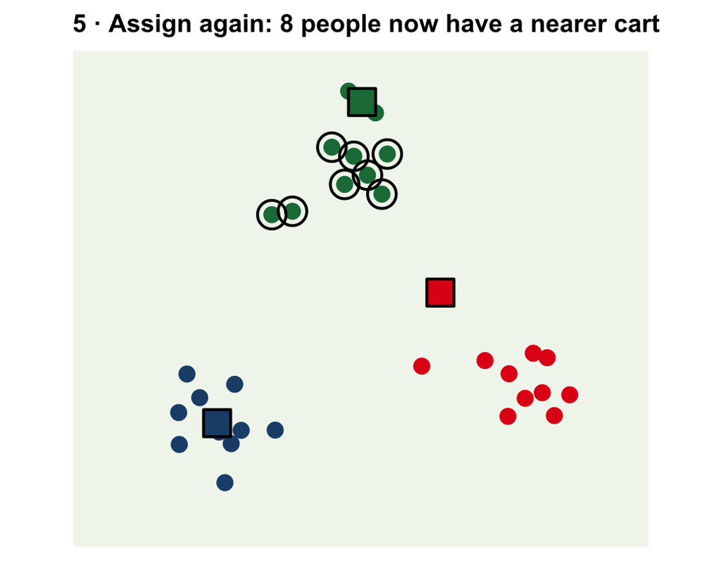

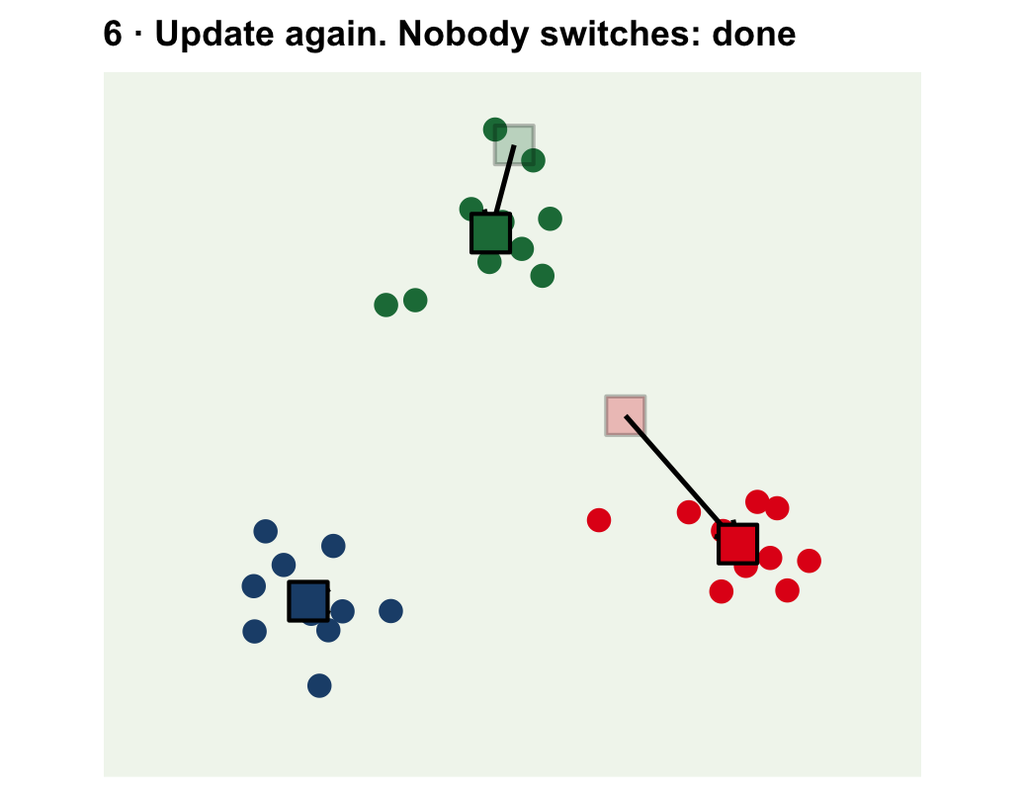

You run three ice-cream carts. Where should they stand so that nobody walks far?

Startk carts at random spots here k = 3

Assigneveryone to the nearest cart

Updateeach cart to the **mean** of its customers

Repeatassign, update … until nobody switches

That is the whole algorithm *k* groups, each described by its mean: k-means. A cart’s final spot is a **centre** (or centroid); its customers are a **cluster**.

## How good is a grouping?

WhatI · k-meansII · DBSCANWrap-up

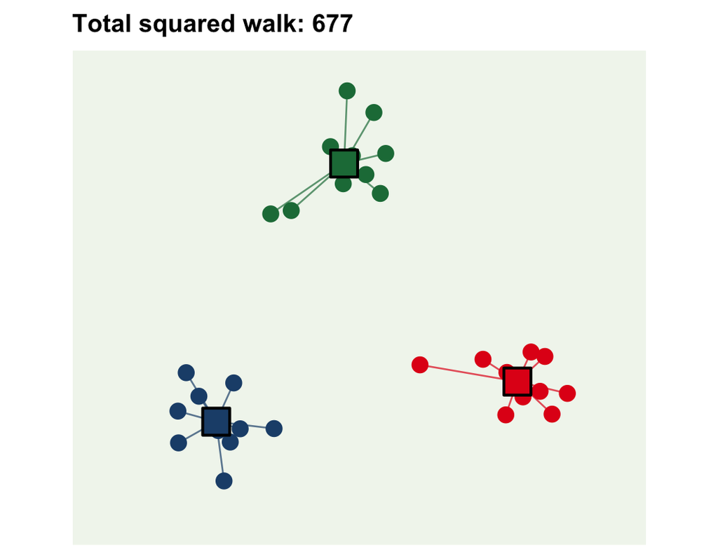

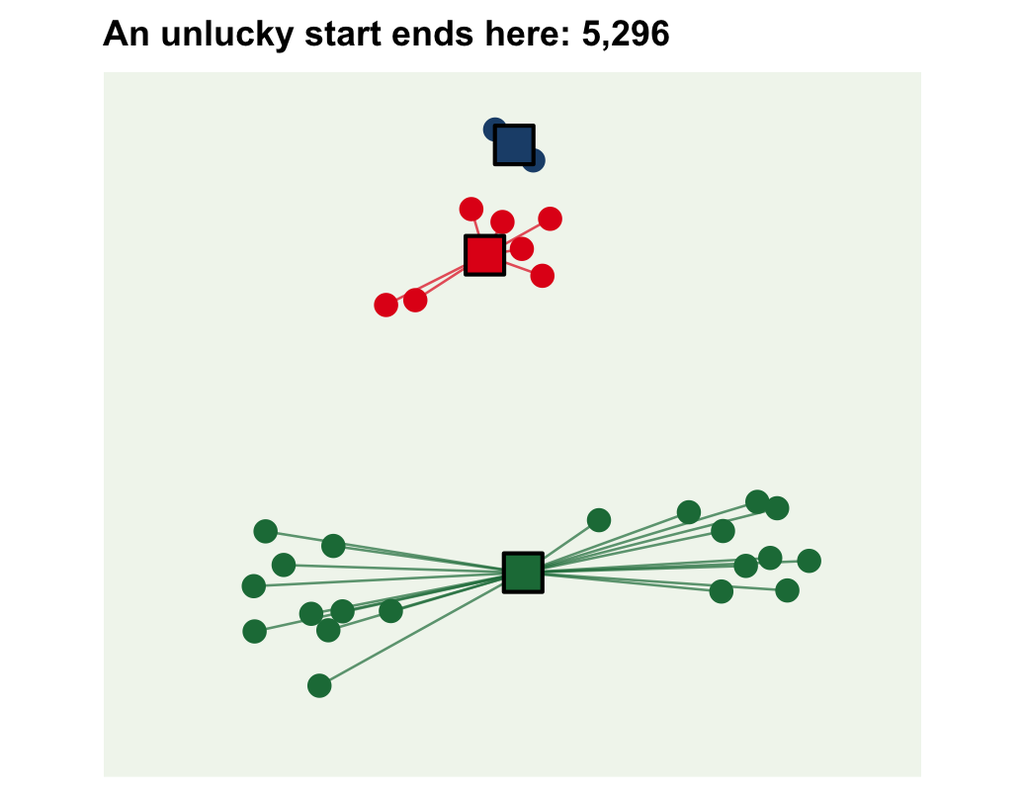

One number: the total squared walk Measure each person’s distance to their cart, square it, add them all up. **Small = tight groups.** R calls it `tot.withinss`.

k-means can get stuck Another random start: two carts share one group, one cart serves two. Nobody wants to switch, so it stops, at 5,296 instead of 677.

`nstart = 25` Run it from 25 random starts and keep the one with the smallest total. It is in every `kmeans()` call in the notebook.

## How many groups? The elbow

WhatI · k-meansII · DBSCANWrap-up

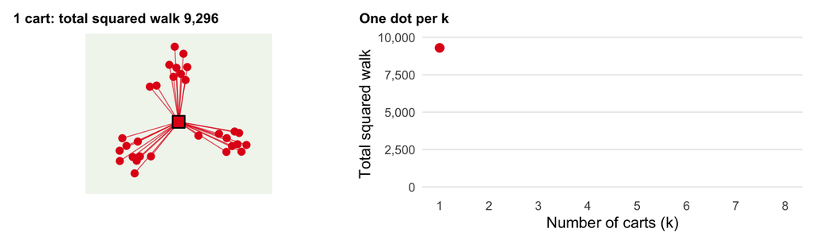

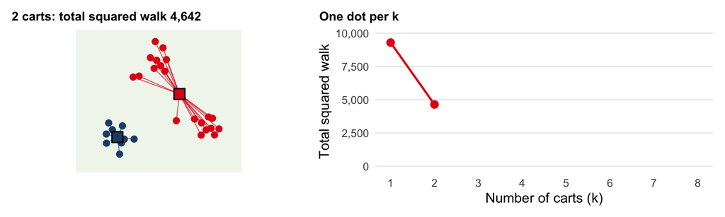

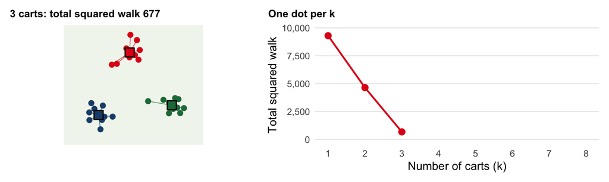

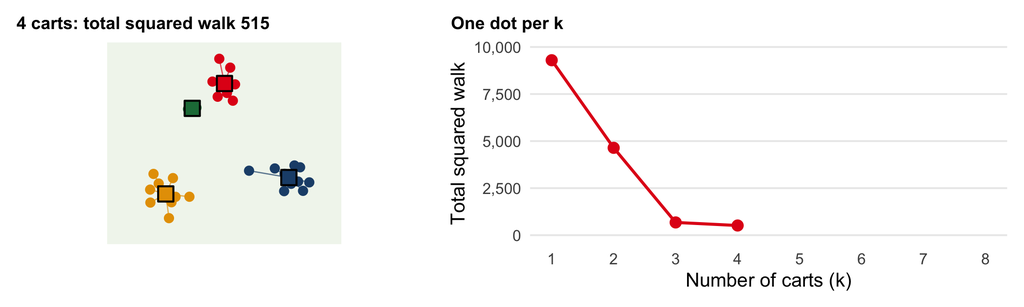

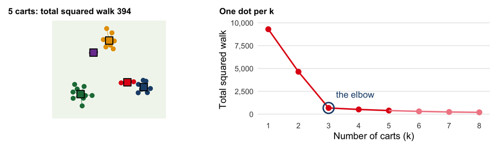

More carts, less walking Always. With 30 carts the total is 0: one each. So “smallest total” cannot choose k.

Big drops, then small Carts 2 and 3 each serve a real group. Cart 4 only splits a group that was already together.

Pick the bend: the elbow The last k that still bought a big drop. Here 3. On real data the bend is often soft: a judgement.

## A second opinion: the silhouette

WhatI · k-meansII · DBSCANWrap-up

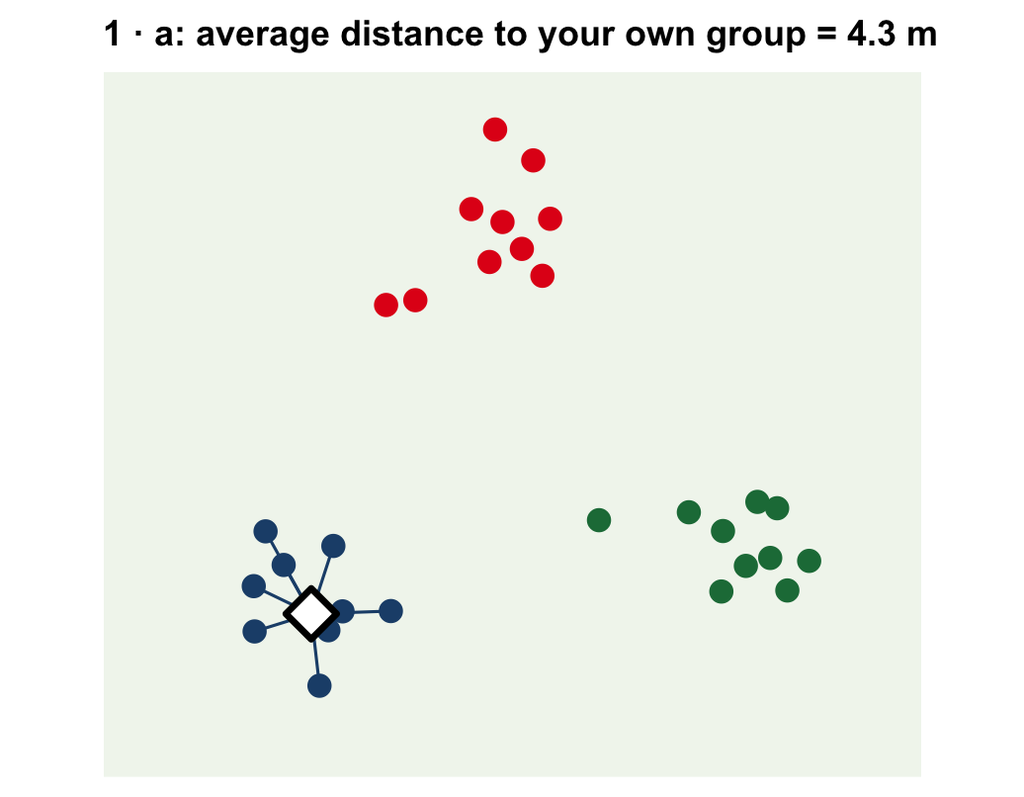

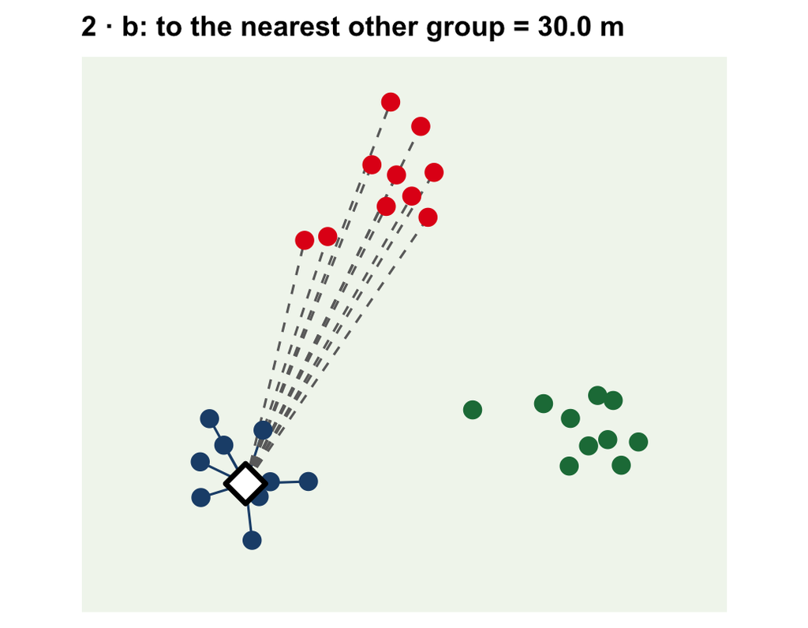

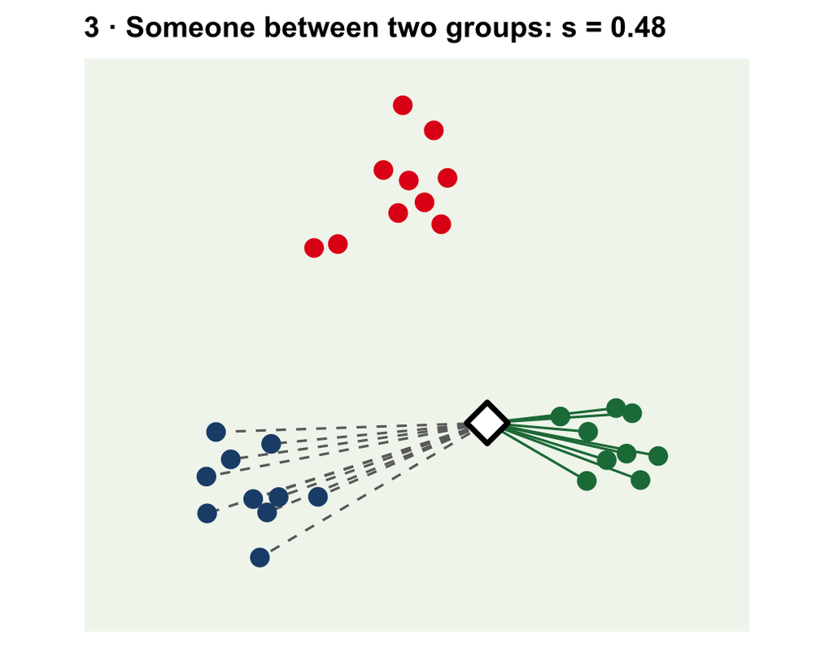

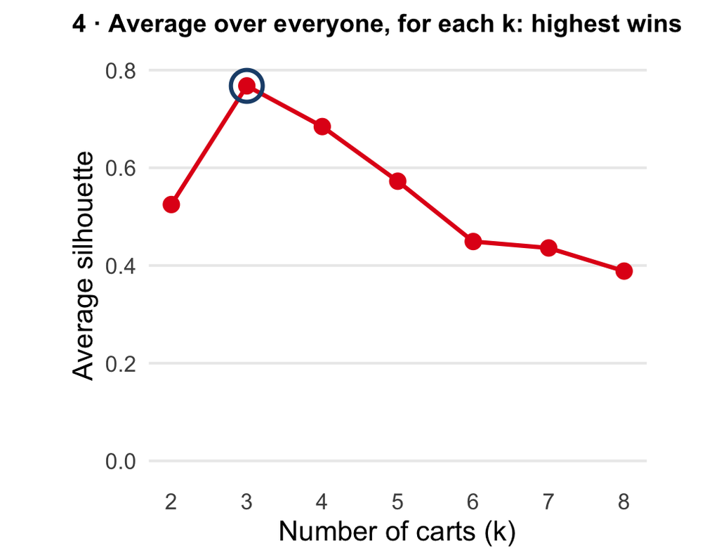

Ask one person: are you clearly in your group, or between two?

a · own group4.3 m on average

b · next group30.0 m on average

silhouette(b − a) ÷ the larger = **0.85**

Reading it Near **1**: clearly in the group. Near **0**: between two groups (this person: 0.48). **Below 0**: probably in the wrong one.

One number per k Average everyone’s silhouette. Unlike the elbow curve it can go **down** when k is too large, so the highest point is the suggestion.

## The data: last week’s map

WhatI · k-meansII · DBSCANWrap-up

**Notebook** lines 36–57 setup, then the first task: plot the two dimensions*code together*

mca_coords |> ggplot(aes(dim_1, dim_2)) + geom_point(size = 4)

1. **36 rows, one per answer**: 18 questions × `_y` or `_n`.
2. **Its place** on last week’s MCA map.
3. **One dot per answer.**

Remember the map **Close** = given by the same people. So a cluster is a set of answers that **go together**.

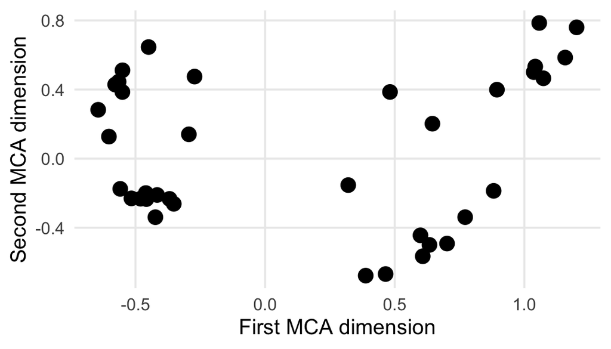

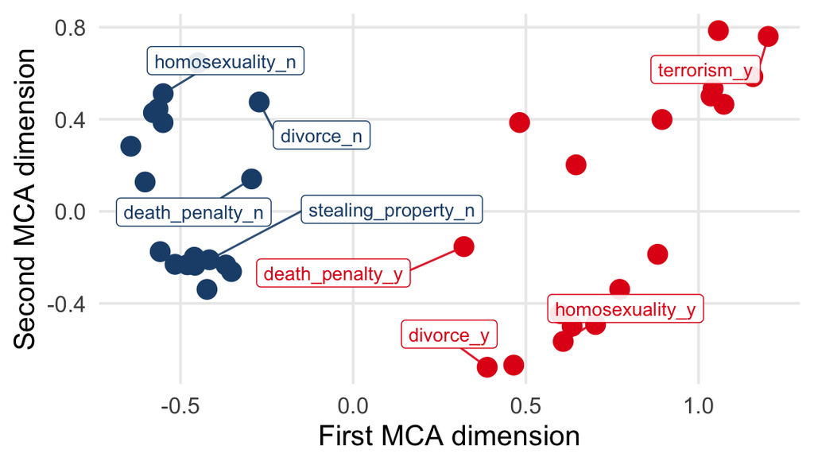

Can you see clusters? How many?

To some extent A tight knot bottom left, a looser group top right. The other two corners are less clear.

## Find k: read the workflow

WhatI · k-meansII · DBSCANWrap-up

**Notebook** lines 59–96 "the complete workflow for finding the correct k": given, ready to run*run together*

eval_kmeans <- function(k) { km <- kmeans(coords, centers = k, nstart = 25) tibble( k = k, tot.withinss = km$tot.withinss, silhouette = mean(silhouette(km$cluster, dist_mat)[, "sil_width"]) ) } map(2:10, eval_kmeans) |> list_rbind()

1. **Run k-means** with k carts, from 25 starts, and keep the best.
2. **The total squared walk** of that run: for the elbow.
3. **Everyone’s silhouette, averaged**: the second opinion.
4. **Do all of that for k = 2, 3, …, 10** and stack the nine rows.

[output not shown]

`set.seed(123)` The starts are random. The seed makes everyone’s numbers the same.

Why start at 2? A silhouette needs a “next group”. With one cluster there is none.

## Your turn A: choose k and meet the clusters

Part I · lines 98–130 · in pairs

1. **Line 98:** look at the two panels. Where is the elbow? Where does the silhouette peak? Which *k* would you pick?
2. **Line 107:** replace `NA` with your *k*.
3. **Lines 111–114:** finish the plot: pipe into a scatter plot and colour the points by `cluster`.
4. **Lines 120–126:** write code that lists which answers are in which cluster.
5. **Line 128:** what is in each cluster? Give each a name. Do the groups make sense?

Syntax you need

```r
optimal_k <- ___                    # your choice

mca_coords |>
  mutate(cluster = as.factor(final_kmeans$cluster)) |>
  ggplot(aes(dim_1, dim_2, colour = ___)) +
  geom_point(size = 4)

mca_coords |>
  mutate(cluster = as.factor(final_kmeans$cluster)) |>
  arrange(cluster) |>               # sort by group
  print(n = Inf)                    # show all 36 rows
```

- `final_kmeans$cluster`: 36 group numbers, one per row, in the order of the table
- `as.factor()` makes them labels, so each group gets its own colour

**Stuck?**

- `centers` error: `optimal_k` is still `NA`
- No colours: `colour = cluster` goes **inside** `aes()`

## Answers A: which k?

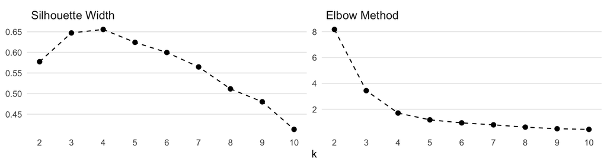

Elbow: 3 or 4 The total falls from 8.2 to 3.4 to 1.7, then only to 1.2. A soft bend.

Silhouette: 4, just 0.66 at k = 4 against 0.65 at k = 3: nearly a tie. After 4 it falls steadily.

So: 4, and say why Both measures allow it. The tie-breaker is whether the four groups **mean something**. That is the next task.

## Solutions A: fit, plot, list

```r
set.seed(123)
optimal_k <- 4

final_kmeans <- kmeans(mca_coords[, 1:2],
                       centers = optimal_k, nstart = 25)

mca_coords |>
  mutate(cluster = as.factor(final_kmeans$cluster)) |>
  ggplot(aes(dim_1, dim_2, colour = cluster)) +
  geom_point(size = 4) +
  theme_minimal() +
  ggsci::scale_colour_uchicago()

mca_coords |>
  mutate(cluster = as.factor(final_kmeans$cluster)) |>
  arrange(cluster) |>
  print(n = Inf)
```

Fit once with the k you chose, colour the map, then list the members.

`kmeans()` returns a list. `$centers` holds the four final cart positions; `$cluster` the group number of each of the 36 answers. `[, 1:2]` keeps the two coordinates and leaves the names out.

```
  dim_1 dim_2
1 -0.45 -0.24
2 -0.50  0.38
3  0.95  0.51
4  0.60 -0.45
```

One colour per cluster, one cluster per corner of the map. The last two lines are styling from the notebook; the first three do the work.

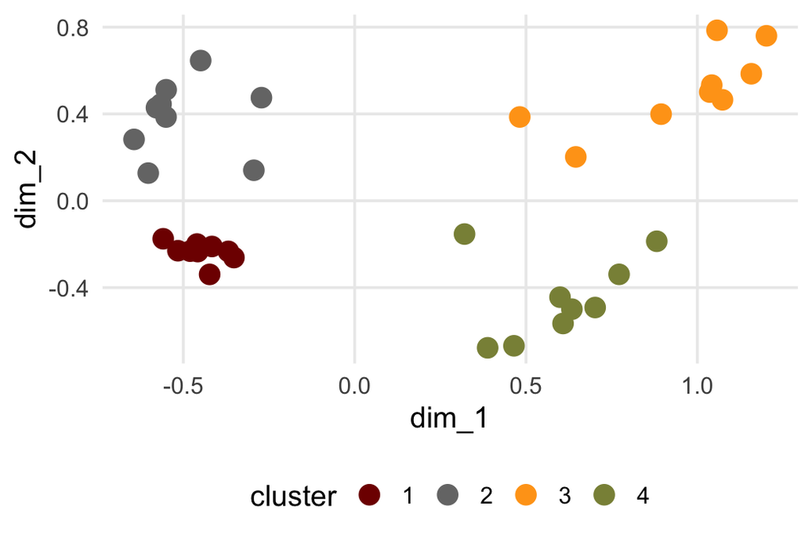

Sorted by cluster, all rows (the first six here). The cluster **numbers are only labels**: on another machine “1” and “3” may swap. Describe clusters by what is in them.

```
# A tibble: 36 × 3
  category                  cluster  dim_1
  <chr>                     <fct>    <dbl>
1 avoid_transport_fare_n    1       -0.559
2 stealing_property_n       1       -0.416
3 cheating_taxes_n          1       -0.516
4 accept_bribes_n           1       -0.458
5 violence_against_spouse_n 1       -0.352
6 violence_against_child_n  1       -0.423
# ℹ 30 more rows
```

## Answers A: what is in each cluster?

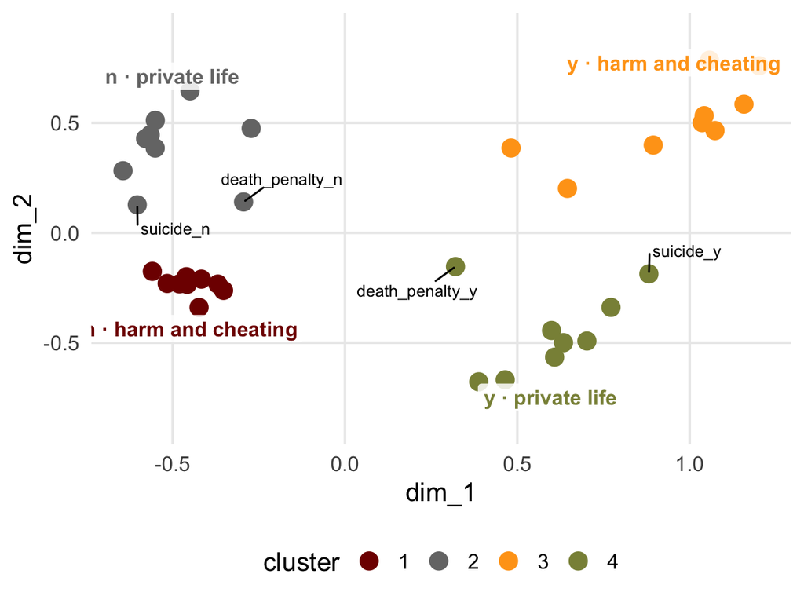

2 kinds of question × 2 answers **Harm and cheating** (stealing, bribes, violence, terrorism …) and **private life** (divorce, abortion, sexuality, euthanasia …), each split into its `_n` and its `_y` answers.

It is last week’s map, in words Left against right: n against y (Dim 1). Top against bottom: which kind of question (Dim 2). k-means found both without being told.

The awkward ones Both death-penalty answers sit near the middle and go with nothing strongly. k-means **must** still put them in a group.

# DBSCAN

Part II

No *k* · groups are crowds · and some points belong to no group

## Where k-means goes wrong

WhatI · k-meansII · DBSCANWrap-up

**Notebook** lines 132–134 "DBSCAN is fundamentally different"*concept*

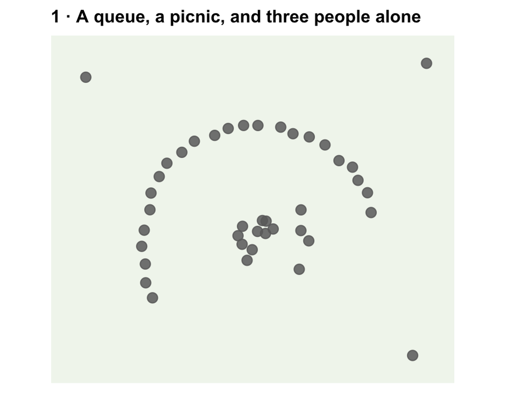

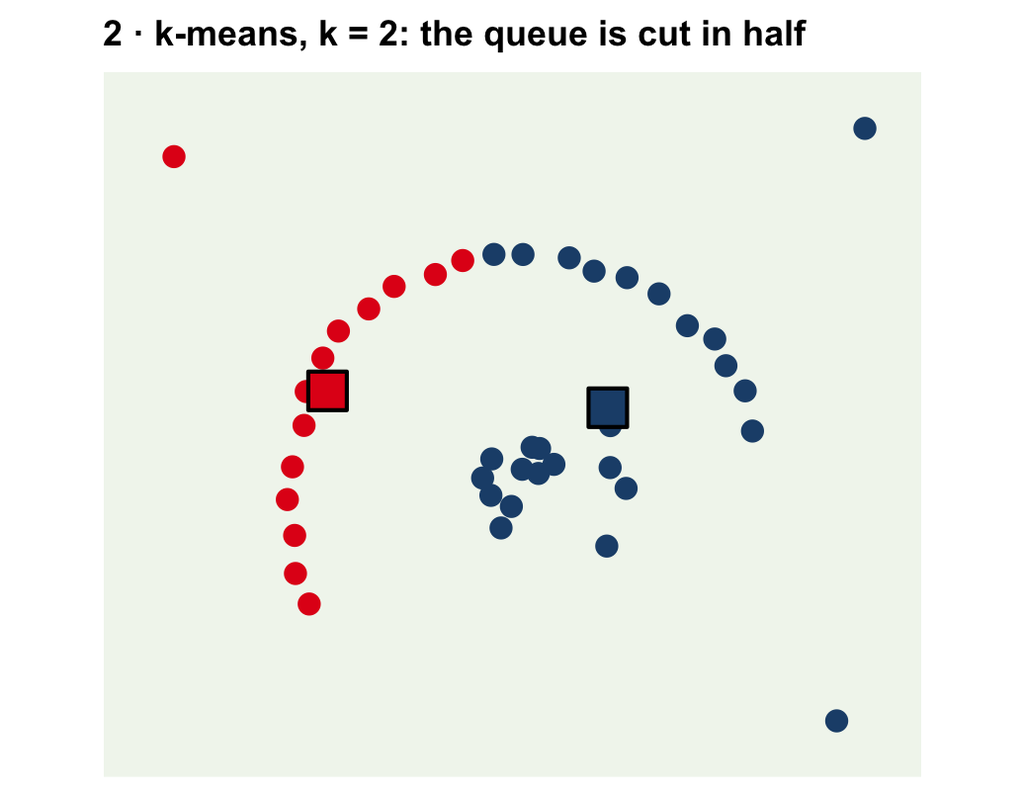

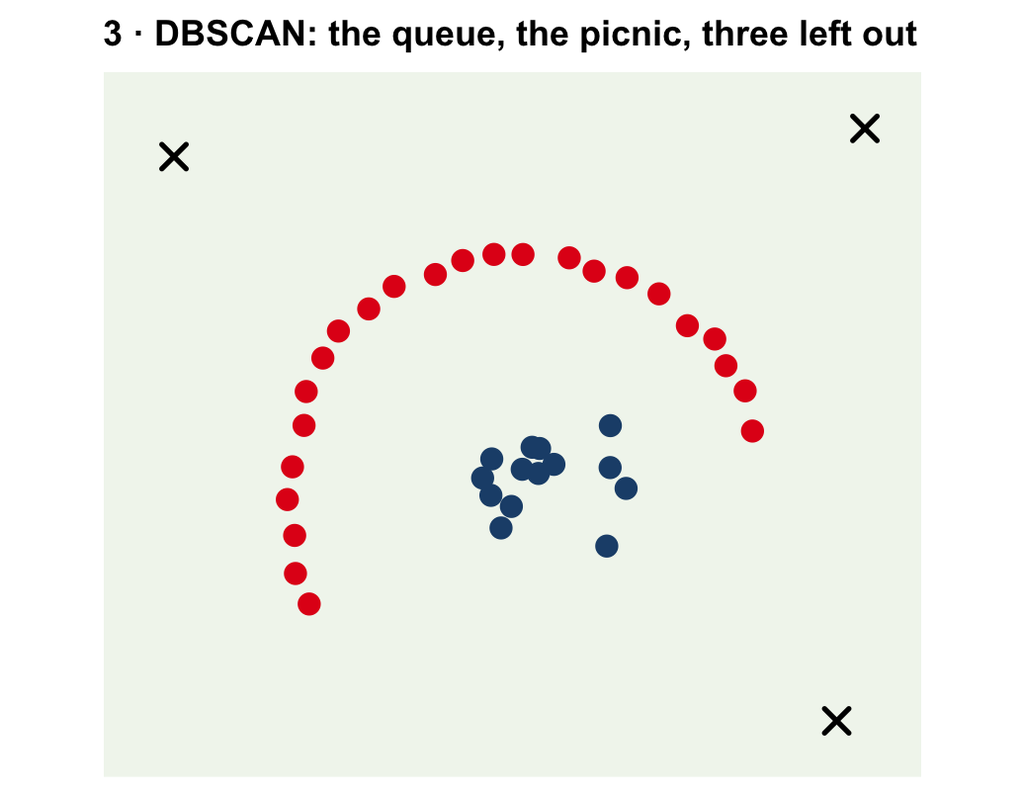

Which groups do you see on this field?

k-means thinks in carts A group is a blob round one centre. A queue has no centre, and the loners **must** join a group.

You thought in crowds A group is where people stand **densely**, whatever its shape.

DBSCAN does what you did No k to choose · any shape · and it may leave points out as **noise**.

## DBSCAN 1: who stands in a crowd?

WhatI · k-meansII · DBSCANWrap-up

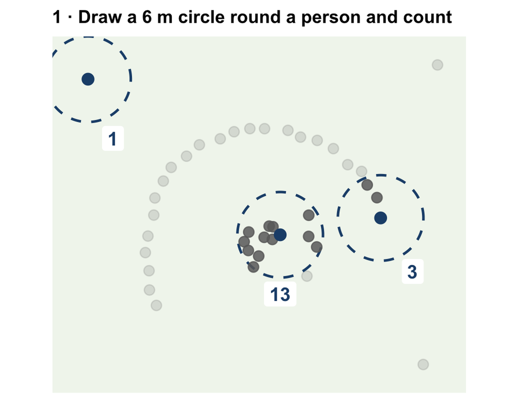

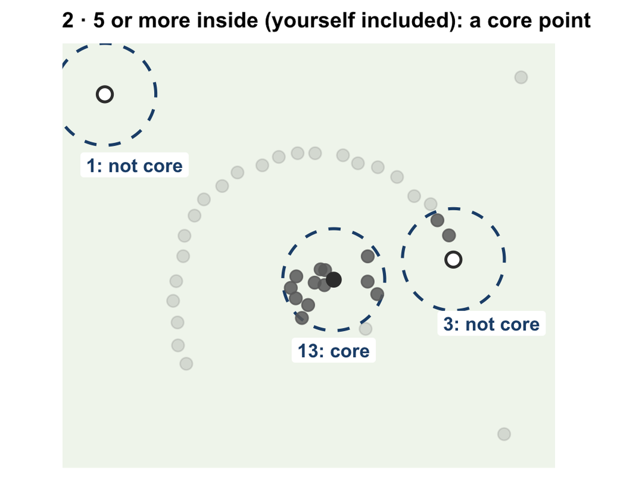

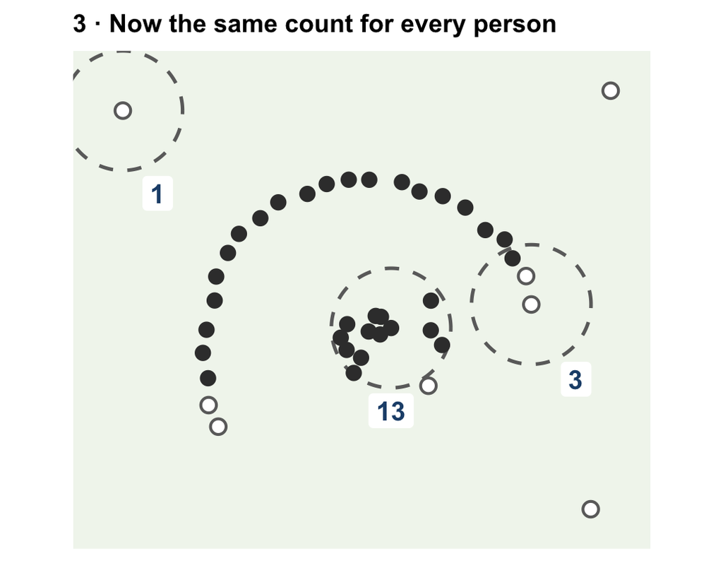

Setting 1`eps` = 6 m: the radius, who counts as **near** you

Setting 2`minPts` = 5: the head count that makes a **crowd**

Three people, three counts: 13, 3 and 1. Who is standing in a crowd?

Core point = in a crowd 13 is 5 or more: a **core point** (solid dot). 3 and 1 are fewer: **not core** (rings).

Then everyone gets the same test One circle and one count per person, before any cluster exists.